```python
import pandas as pd
import os
```

#### Merge 12 months sales data into one

```python
files = [file for file in os.listdir('./data')]
full_data = pd.DataFrame()
for file in files:
    data = pd.read_csv('./data/'+file)
    full_data = pd.concat([full_data, data])
    full_data.to_csv('full_data.csv',index = False)
```

#### Read full data

```python
data = pd.read_csv('./full_data.csv')
data.head()
```

|  | Order ID | Product | Quantity Ordered | Price Each | Order Date | Purchase Address |
| --- | --- | --- | --- | --- | --- | --- |
| 0 | 176558 | USB-C Charging Cable | 2 | 11.95 | 04/19/19 08:46 | 917 1st St, Dallas, TX 75001 |
| 1 | NaN | NaN | NaN | NaN | NaN | NaN |
| 2 | 176559 | Bose SoundSport Headphones | 1 | 99.99 | 04/07/19 22:30 | 682 Chestnut St, Boston, MA 02215 |
| 3 | 176560 | Google Phone | 1 | 600 | 04/12/19 14:38 | 669 Spruce St, Los Angeles, CA 90001 |
| 4 | 176560 | Wired Headphones | 1 | 11.99 | 04/12/19 14:38 | 669 Spruce St, Los Angeles, CA 90001 |

#### Clean up data since there are multiple NAs and removing useless rows.

```python
data.dropna(inplace = True)
```

```python
data = data[data['Order Date'].str[0:2] != 'Or']
```

```python
data['Quantity Ordered'] = pd.to_numeric(data['Quantity Ordered'])
data['Price Each']=pd.to_numeric(data['Price Each'])
```

### Add additional columns to help in analyzing process

#### Add Month Column

```python
data['Month'] = data['Order Date'].str[0:2]
data['Month'] = data['Month'].astype('int32')
```

#### Add Total Sales Column

```python
data['Sales'] = data['Quantity Ordered'] * data['Price Each']
data.head()
```

|  | Order ID | Product | Quantity Ordered | Price Each | Order Date | Purchase Address | Month | Sales |
| --- | --- | --- | --- | --- | --- | --- | --- | --- |
| 0 | 176558 | USB-C Charging Cable | 2 | 11.95 | 04/19/19 08:46 | 917 1st St, Dallas, TX 75001 | 4 | 23.90 |
| 2 | 176559 | Bose SoundSport Headphones | 1 | 99.99 | 04/07/19 22:30 | 682 Chestnut St, Boston, MA 02215 | 4 | 99.99 |
| 3 | 176560 | Google Phone | 1 | 600.00 | 04/12/19 14:38 | 669 Spruce St, Los Angeles, CA 90001 | 4 | 600.00 |
| 4 | 176560 | Wired Headphones | 1 | 11.99 | 04/12/19 14:38 | 669 Spruce St, Los Angeles, CA 90001 | 4 | 11.99 |
| 5 | 176561 | Wired Headphones | 1 | 11.99 | 04/30/19 09:27 | 333 8th St, Los Angeles, CA 90001 | 4 | 11.99 |

## Best month for sales? How much was earned that month?

#### -To answer this question, first I need to group the total sales data by the month column I just created previously and graph it to visualize the result.

```python
results = data.groupby('Month').sum()
```

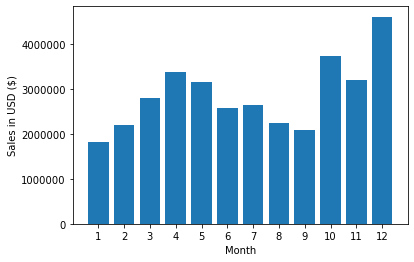

```python
import matplotlib.pyplot as plt

month = range(1,13)
plt.bar(month, results['Sales'])
plt.xticks(month)
plt.ylabel('Sales in USD ($)')
plt.xlabel('Month')
```

#### -Looking at the graph, I can conclude that the total sales peaks on December.

#### -In my opinion, the reason for that is that it is the holiday season, people tend to be more generous with their spending.

## What city has highest number of sales?

#### - To approach this question, first I need to establish a City columns base on the Purchase Address to filter the data.

#### - I also kept the state of each city to separate entries of cities with the same name but in different state (I.E: Portland (ME), Portland (OR))

```python
def getcity(address):
    return address.split(',')[1]
def getstate(address):
    return address.split(',')[2].split(' ')[1]
data['City'] = data['Purchase Address'].apply(lambda x: f"{getcity(x)} ({getstate(x)})")
data.head()
```

|  | Order ID | Product | Quantity Ordered | Price Each | Order Date | Purchase Address | Month | Sales | City |
| --- | --- | --- | --- | --- | --- | --- | --- | --- | --- |
| 0 | 176558 | USB-C Charging Cable | 2 | 11.95 | 04/19/19 08:46 | 917 1st St, Dallas, TX 75001 | 4 | 23.90 | Dallas (TX) |
| 2 | 176559 | Bose SoundSport Headphones | 1 | 99.99 | 04/07/19 22:30 | 682 Chestnut St, Boston, MA 02215 | 4 | 99.99 | Boston (MA) |
| 3 | 176560 | Google Phone | 1 | 600.00 | 04/12/19 14:38 | 669 Spruce St, Los Angeles, CA 90001 | 4 | 600.00 | Los Angeles (CA) |
| 4 | 176560 | Wired Headphones | 1 | 11.99 | 04/12/19 14:38 | 669 Spruce St, Los Angeles, CA 90001 | 4 | 11.99 | Los Angeles (CA) |
| 5 | 176561 | Wired Headphones | 1 | 11.99 | 04/30/19 09:27 | 333 8th St, Los Angeles, CA 90001 | 4 | 11.99 | Los Angeles (CA) |

```python
df1 = data.groupby('City').sum().sort_values('Sales')
```

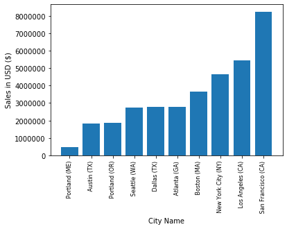

```python
import matplotlib.pyplot as plt

#cities = [city for city, data in data.groupby('City')]
cities = df1.index
plt.bar(cities, df1['Sales'])
plt.xticks(cities,rotation ='vertical', size=8)
plt.ylabel('Sales in USD ($)')
plt.xlabel('City Name')
```

## What time should we display ads to maximize likelihood of purchase?

#### - Same as before, I need to create a new column for hour to filter the data through.

```python
data['Order Date'] = pd.to_datetime(data['Order Date'])
data['Hour'] = data['Order Date'].dt.hour
data['Minute'] = data['Order Date'].dt.minute
data.head()
```

|  | Order ID | Product | Quantity Ordered | Price Each | Order Date | Purchase Address | Month | Sales | City | Hour | Minute |
| --- | --- | --- | --- | --- | --- | --- | --- | --- | --- | --- | --- |
| 0 | 176558 | USB-C Charging Cable | 2 | 11.95 | 2019-04-19 08:46:00 | 917 1st St, Dallas, TX 75001 | 4 | 23.90 | Dallas (TX) | 8 | 46 |
| 2 | 176559 | Bose SoundSport Headphones | 1 | 99.99 | 2019-04-07 22:30:00 | 682 Chestnut St, Boston, MA 02215 | 4 | 99.99 | Boston (MA) | 22 | 30 |
| 3 | 176560 | Google Phone | 1 | 600.00 | 2019-04-12 14:38:00 | 669 Spruce St, Los Angeles, CA 90001 | 4 | 600.00 | Los Angeles (CA) | 14 | 38 |
| 4 | 176560 | Wired Headphones | 1 | 11.99 | 2019-04-12 14:38:00 | 669 Spruce St, Los Angeles, CA 90001 | 4 | 11.99 | Los Angeles (CA) | 14 | 38 |
| 5 | 176561 | Wired Headphones | 1 | 11.99 | 2019-04-30 09:27:00 | 333 8th St, Los Angeles, CA 90001 | 4 | 11.99 | Los Angeles (CA) | 9 | 27 |

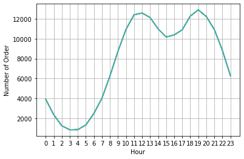

```python
result = data.groupby('Hour').count()
hours = result.index
plt.plot(hours,result)
plt.xticks(hours)
plt.grid()
plt.xlabel('Hour')
plt.ylabel('Number of Order')
```

#### - Looking at the graph, The best time frames for advertisement should be around 11am-1pm and 6pm-8pm

#### - 11am-1pm matches the time frame for lunch break for office workers

#### - 6pm-8pm is around the time that most people just came home and relax after a day at work

## What products are most often sold together?

#### - To answer this question, I have to filter data for different product orders that have the same orderID since that is the indication that the products are sold together

```python
df=data.copy()[data['Order ID'].duplicated(keep= False)]
df['Grouped'] =df.groupby('Order ID')['Product'].transform(lambda x: ','.join(x))
```

```python
df= df[['Order ID','Grouped']].drop_duplicates()
df.head(10)
```

|  | Order ID | Grouped |
| --- | --- | --- |
| 3 | 176560 | Google Phone,Wired Headphones |
| 18 | 176574 | Google Phone,USB-C Charging Cable |
| 30 | 176585 | Bose SoundSport Headphones,Bose SoundSport Hea... |
| 32 | 176586 | AAA Batteries (4-pack),Google Phone |
| 119 | 176672 | Lightning Charging Cable,USB-C Charging Cable |
| 129 | 176681 | Apple Airpods Headphones,ThinkPad Laptop |
| 138 | 176689 | Bose SoundSport Headphones,AAA Batteries (4-pack) |
| 189 | 176739 | 34in Ultrawide Monitor,Google Phone |
| 225 | 176774 | Lightning Charging Cable,USB-C Charging Cable |
| 233 | 176781 | iPhone,Lightning Charging Cable |

#### -From the filtered data, I need to figure out what is the combination of items that are often sold together

#### -The list below show the top 10 most common combination of 2 items that are often sold together.

```python
from itertools import combinations
from collections import Counter
count = Counter()

for row in df['Grouped']:
    row_list = row.split(',')
    count.update(Counter(combinations(row_list,2)))

for key, value in count.most_common(10):
    print(key,value)
```

```
('iPhone', 'Lightning Charging Cable') 1005
('Google Phone', 'USB-C Charging Cable') 987
('iPhone', 'Wired Headphones') 447
('Google Phone', 'Wired Headphones') 414
('Vareebadd Phone', 'USB-C Charging Cable') 361
('iPhone', 'Apple Airpods Headphones') 360
('Google Phone', 'Bose SoundSport Headphones') 220
('USB-C Charging Cable', 'Wired Headphones') 160
('Vareebadd Phone', 'Wired Headphones') 143
('Lightning Charging Cable', 'Wired Headphones') 92
```

## What is the most sold product?

#### - To get this insight, I filtered the data through product name and get their total quantity ordered

```python
result = data.groupby('Product')['Quantity Ordered'].sum().sort_values()
df2= pd.DataFrame(data = result)
product = result.index
prices = data.groupby('Product').mean()['Price Each']
prices_df = pd.DataFrame(prices)
df2= df2.join(prices_df, how = 'inner')
```

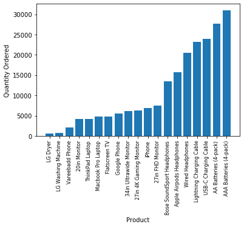

```python
plt.bar(product,result)
plt.xticks(product, rotation = 'vertical', size=8)
plt.ylabel('Quantity Ordered')
plt.xlabel('Product')
plt.show()
```

#### - It seems like tripple A batteries sold the most. My guess is that it is because it is one of the cheapers item of the store

#### - To test my theory, I will add another Y axis for unit price of the product to see if their is a visable corelation.

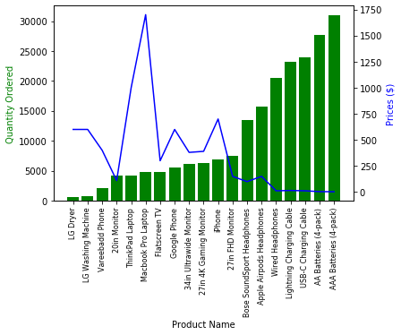

```python
Quant_Ordered = df2['Quantity Ordered']
Price = df2['Price Each']
fig, ax1 = plt.subplots()

ax2 = ax1.twinx()
ax1.bar(product, Quant_Ordered, color ='g')
ax2.plot(product,Price, 'b-')

ax1.set_xlabel('Product Name')
ax1.set_ylabel('Quantity Ordered',color='g')
ax2.set_ylabel('Prices ($)',color= 'b')
ax1.set_xticklabels(product, rotation='vertical', size=8)
plt.show()
```

#### - The overall demand of a product might also have a role. Together with pricing, they influence the total quantity sold.